# evolSOM vignette

Santiago Prochetto

Last modified “2024-06-13”

# About

In recent years, we have witnessed a surge in technological advancements in the field of life sciences. Researchers now have access to extensive biobanks and can collect vast amounts of multimodal data, including data from omics studies across multiple organisms, which is crucial for understanding evolution. As technical developments continue to progress, the demand for information systems capable of managing heterogeneous data is on the rise. One of the key challenges of this new era is the development of robust tools capable of integrating diverse data types to uncover hidden patterns and relationships among heterogeneous sources. We here introduce evolSOM, a novel tool based on unsupervised machine learning that facilitates the discovery of variations between multimodal data and offers an intuitive way to visualize hidden patterns within complex data matrices. Specifically, evolSOM clusters genes and/or phenotypic traits based on their expression patterns and maps these biological variables across different species to assess their conservation. This vignette provides a detailed overview of the most essential functions within the evolSOM package and outlines the overall process for analyzing the displacement of biological variables. The displacement of biological variables is a crucial aspect, as it allows us to uncover intrinsic evolutionary processes and changes. The general steps for using evolSOM are as follows:

1. Import data and perform scaling.
2. Construct a reference SOM (Self-Organizing Map).
3. Map biological variables within the reference SOM.
4. Characterize displacement types.
5. Create a network dataframe to quantify and visualize displacements.
6. Generate displacement plots to gain insights into the data.

# Installation

```r
#devtools::install_github("sanprochetto/evolSOM")
library(evolSOM)
library(ggplot2)
```

# Example: Using evolSOM to Discover Potential Gene Drivers for Leaf Development in Grasses

In this example, we will demonstrate how to use evolSOM to identify potential gene drivers for leaf development in grasses. We’ll go through the following steps:

## Step 1: Importing Data and Scaling

### 1.1 Data Import

First, we need to import our dataset. The dataset consists of a dataframe containing a list of genes and phenotypic traits. These genes and traits have been measured in leaf segments at four different developmental stages and across three closely related species. Additionally, we require an extra dataframe providing useful information about each biological variable, which will be used in Step 3.1. This information might include details such as the variable type (gene or phenotypic trait), the biological processes in which the variable is involved, the gene family to which the variable belongs, and more.

```r
#Traits expression data (genes + phenotype)
datSOM_control <- read.csv("../inst/extdata/dataC3.csv", row.names = 1) #Load data from control condition.
head(datSOM_control)
```

```
#>                        C3_S1        C3_S3        C3_S5        C3_S7
#> VB Distance     153.62890000 217.85020000 202.99400000 201.72700000
#> VB Density       16.24429677  13.74127943  17.06579913  27.92705879
#> 1 VB / Total VB   0.25449717   0.23334214   0.21335004   0.20526294
#> VB Diameter      46.94168767  41.86461546  38.73264891  30.33772343
#> VB Area %         0.03705901   0.02472777   0.02370764   0.02200877
#> IBS Cell size    63.84000000  66.80600000  67.06573753  58.74200000
```

```r
datSOM_test1 <- read.csv("../inst/extdata/dataPK.csv", row.names = 1) #Load data from first test/treatment condition.
head(datSOM_test1)
```

```
#>                        PK_S1        PK_S3        PK_S5       PK_S7
#> VB Distance     106.38600000 131.87600000 164.17500000 247.8660000
#> VB Density       58.29631910  41.24440327  36.53311057  37.8920913
#> 1 VB / Total VB   0.48551693   0.26945086   0.24035201   0.2600038
#> VB Diameter      31.87324198  25.25162621  24.53899877  22.6388471
#> VB Area %         0.04165525   0.01999988   0.01500147   0.0131221
#> IBS Cell size    29.38600000  29.70600000  31.02890125  27.2040000
```

```r
datSOM_test2 <- read.csv("../inst/extdata/dataC4.csv", row.names = 1) #Load data from second test/treatment condition.
head(datSOM_test2)
```

```
#>                        C4_S1        C4_S3        C4_S5        C4_S7
#> VB Distance     182.68200000 114.46896400 100.14900000 100.12600000
#> VB Density       47.26766497  64.36986476  71.07727666  71.77854606
#> 1 VB / Total VB   0.41048688   0.19180276   0.15728947   0.14436289
#> VB Diameter      48.89710673  29.78487596  25.78403509  23.28320159
#> VB Area %         0.08228664   0.05068694   0.04097582   0.02841255
#> IBS Cell size   135.41307220 181.34725810 188.98290370 194.53952300
```

```r
#Traits names and information (tags)
classSOM <-  read.csv("../inst/extdata/class_SOM.csv", row.names = 1) #First column must be the name of biological variable/gen
head(classSOM)
```

```
#>           bio_var Class1 Class2 Class3
#> 1     VB Distance    PhT     vb   <NA>
#> 2      VB Density    PhT     vb   <NA>
#> 3 1 VB / Total VB    PhT     vb   <NA>
#> 4     VB Diameter    PhT     vb   <NA>
#> 5       VB Area %    PhT     vb   <NA>
#> 6   IBS Cell size    PhT     bs   <NA>
```

### 1.2 Scaling

After importing the data, the next crucial step is to scale each biological variable to unit variance. This ensures that all variables have the same level of influence during the analysis, preventing any variable from dominating the results due to differences in scale. Scaling is essential for accurate and meaningful insights from evolSOM.

We can achieve scaling using the *scale_condition()* function, which scales the data from each condition individually. In this case, each condition represents the biological variables measured in the three species. The output is a list containing one dataframe for each condition/species. The control condition should be the first element in the list:

```r
datSOM.scaled <- scale_condition(datSOM_control, datSOM_test1, datSOM_test2,
                               rnames= row.names(datSOM_control),
                               condition_names = c("C3", "PK", "C4")) #Names of the species

head(datSOM.scaled[[1]])
```

```
#>                      C3_S1      C3_S3       C3_S5      C3_S7
#> VB Distance     -1.4610113  0.8064836  0.34759907  0.3069287
#> VB Density      -0.3504202 -0.8905245 -0.19014465  1.4310894
#> 1 VB / Total VB  1.2622110  0.3122963 -0.60049495 -0.9740124
#> VB Diameter      1.0068654  0.3849583 -0.03657783 -1.3552458
#> VB Area %        1.4796762 -0.3109504 -0.46004812 -0.7086776
#> IBS Cell size   -0.0469666  0.6906558  0.75370662 -1.3973958
```

```r
head(datSOM.scaled[[2]])
```

```
#>                       PK_S1      PK_S3      PK_S5      PK_S7
#> VB Distance     -1.03355052 -0.4402207  0.1659310  1.3078402
#> VB Density       1.45725249 -0.1652610 -0.7310928 -0.5608987
#> 1 VB / Total VB  1.49009920 -0.3754059 -0.6506318 -0.4640615
#> VB Diameter      1.42448687 -0.1633764 -0.3576583 -0.9034522
#> VB Area %        1.46206258 -0.1826078 -0.5671837 -0.7122710
#> IBS Cell size    0.05378119  0.2517252  1.0487198 -1.3542262
```

```r
head(datSOM.scaled[[3]])
```

```
#>                     C4_S1       C4_S3      C4_S5      C4_S7
#> VB Distance      1.463063 -0.17578304 -0.6432388 -0.6440416
#> VB Density      -1.451400  0.12791564  0.6365334  0.6869507
#> 1 VB / Total VB  1.476640 -0.25267841 -0.5543298 -0.6696317
#> VB Diameter      1.428650 -0.08334488 -0.5192094 -0.8260958
#> VB Area %        1.372912  0.01241401 -0.4139195 -0.9714062
#> IBS Cell size   -1.477497  0.26997756  0.5169701  0.6905489
```

## Step 2 - Build a reference SOM

### 2.1 Optimal size of the grid

Before constructing the reference SOM, it’s essential to estimate the optimal size of the grid. The optimal size is where all expression patterns in your data are accurately represented by neurons, ensuring that each pattern is unique. The grid size depends on the number of conditions under which the data was measured. Estimating the grid size manually can be challenging, time-consuming, and may require several iterations, especially for those who are not familiar with Self-Organizing Maps (SOM). To streamline this process, we provide a script that automates the search for the optimum grid size using the *opt_map_size()* function. The result, map_size, will provide you with the optimal grid dimensions.

```r
map_size <- opt_map_size(data = na.omit(datSOM.scaled[[1]]), # Reference species data (without NA)
                     threshold = 0.8,          # Maximum allowed correlation for neurons
                     init_dim = 5,  # Initial grid size (e.g., 5x5)
                     max_iterations = 10)   # Maximum iterations when training the SOM model
```

```
#> The optimum grid size for this data is 3 x 2
```

```r
map_size
```

[output not shown]

### 2.2 Build reference SOM

To build the reference SOM, we use functions from the kohonen and aweSOM packages:

```r
train.data <- as.matrix(na.omit(datSOM.scaled[[1]])) # Select variables for the reference/control condition
dim1<- map_size[["grid_dim1"]]
dim2<- map_size[["grid_dim2"]]
set.seed(100) # Set the random number generator seed for reproducibility
# Initialize the SOM using the aweSOM package
  init <- aweSOM::somInit(train.data, dim1, dim2)
  # Train the SOM using the kohonen package
  model.som <- kohonen::som(train.data,
                          grid = kohonen::somgrid(dim1, dim2, "hexagonal"),
                    rlen = 1000, alpha = c(0.1, 0.001),
                    dist.fcts = "euclidean", init = init)

  # Visualize the reference SOM using the aweSOM package
  aweSOM::aweSOMplot(som = model.som, type = "Line", data = train.data,
           variables = colnames(train.data),
           values = "prototypes", size= 400)
```

[interactive chart not shown]

## Step 3 - Map biological variables within the reference SOM.

### 3.1 Create mappings

Let’s briefly explain how to map biological variables within the reference SOM. In this step, we utilize the *create_mappings()* function to create mappings and class assignments based on a trained model and input data. The mappings object stores valuable information about the mappings, such as class assignments and number of biological variables allocated to each neuron.

```r
mappings <- create_mappings(model = model.som,
                            train_data = train.data,
                            data_list = datSOM.scaled,
                            condition_names = names(datSOM.scaled),
                            classes = classSOM)

#Explore info inside mappings:
head(mappings[["classes"]], 15)
```

```
#>            bio_var Class1 Class2 Class3 C3 PK C4 control_condition
#> 1      VB Distance    PhT     vb   <NA>  3  2  4                 3
#> 2       VB Density    PhT     vb   <NA>  2  4  6                 2
#> 3  1 VB / Total VB    PhT     vb   <NA>  4  4  4                 4
#> 4      VB Diameter    PhT     vb   <NA>  1  4  4                 1
#> 5        VB Area %    PhT     vb   <NA>  4  4  4                 4
#> 6    IBS Cell size    PhT     bs   <NA>  1  1  6                 1
#> 7       IBS Area %    PhT     bs   <NA>  5  4  3                 5
#> 8    OBS Cell size    PhT     bs   <NA>  1  3 NA                 1
#> 9       OBS Area %    PhT     bs   <NA>  3  1 NA                 3
#> 10     M Cell size    PhT  other   <NA>  1  5  3                 1
#> 11             Sv*    PhT  other   <NA>  5  4  4                 5
#> 12             Sb*    PhT  other   <NA>  2  4  6                 2
#> 13       Leaf Size    PhT  other   <NA>  1  3  3                 1
#> 14    1 VB Density    PhT     vb   <NA>  2  4  4                 2
#> 15    2 VB Density    PhT     vb   <NA>  2  4  6                 2
```

```r
head(mappings[["neurons_sizes"]],15)
```

```
#>    Neuron size condition
#> 1       1 1519        C3
#> 2       2 1486        C3
#> 3       3  997        C3
#> 4       4 2320        C3
#> 5       5  826        C3
#> 6       6 2601        C3
#> 7       1 1075        PK
#> 8       2 1110        PK
#> 9       3 1360        PK
#> 10      4 2469        PK
#> 11      5 1222        PK
#> 12      6 2514        PK
#> 13      1 1508        C4
#> 14      2 1391        C4
#> 15      3 1155        C4
```

### 3.2 Neurons sizes graph

Now, let’s take a look at the neuron sizes graph to gain insights into the number of biological variables residing within each neuron:

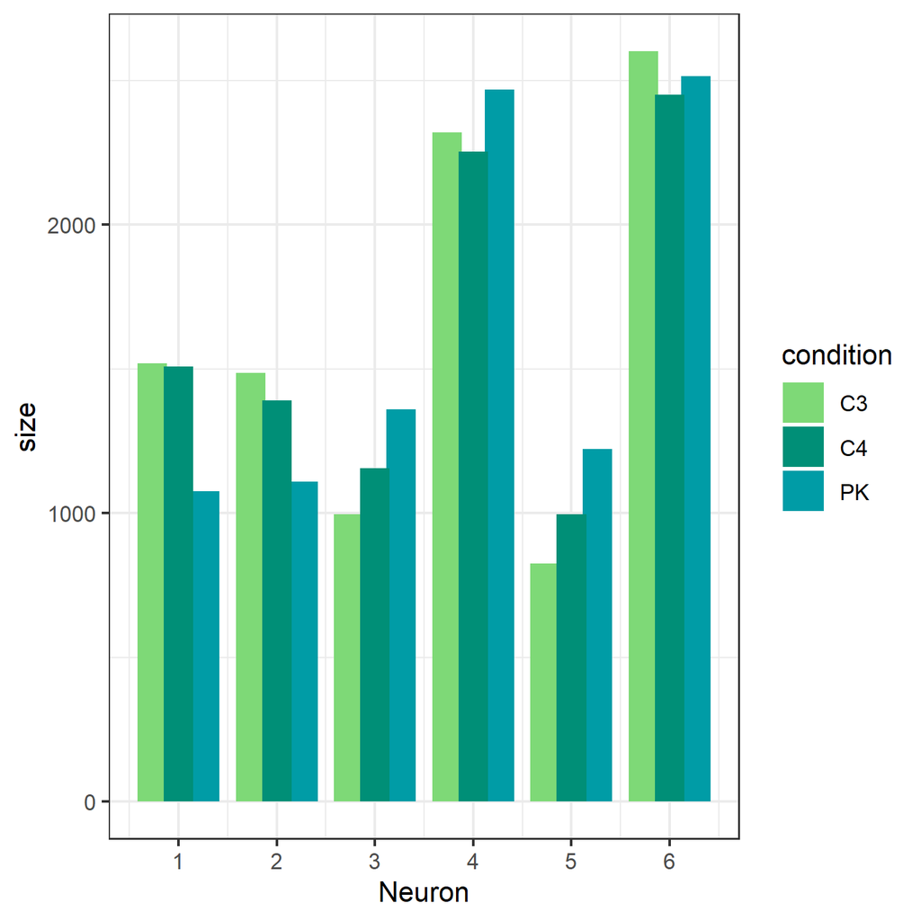

```r
figure <- ggplot(mappings[["neurons_sizes"]], aes(x = Neuron, y = size, fill = condition)) +
   geom_bar(stat = "identity", position = position_dodge(width = 0.8)) +
    scale_x_continuous(breaks = seq(1, 6, 1)) +
  scale_fill_manual(values = c("#7ed977", "#008f77", "#009ca6" ))+
 theme_bw()

figure
```

## Step 4 - Detect and count displacements

### 4.1 - Characterizing displacement types

To uncover hidden patterns, the package identifies movements, or displacements, of biological variables among neurons within the Self-Organizing Map (SOM). The data series can be temporal (i.e., different times of an experiment, or tissues with a differential degree of development) or not temporal (i.e., different tissues or organs). If the cross-correlation is maximum at the middle point of the data series, that is the two series are identical, conservation is observed. When the correlation is maximum at the right part of the middle point of the series and surpasses the *delay_threshold*, it indicates a delay displacement, this means a delay in the expression of the biological variable under analysis in the test condition with respect to the control condition. Similarly, if the correlation is maximum at the left part of the middle point of the series, it indicates an early displacement (early expression in test with respect to control condition). Conversely, a negative cross-correlation lower than the *flip_threshold* indicates a flip, that is, a completely opposite behavior in the test condition with respect to the reference one. While the terms “early” and “delay” might sound as time-related, in non-temporal data they represent a shift in the sequence of activation of a biological variable compared to the reference condition and it will hardly depend on the particular order of the measurements in the data series chosen by the user. The measurements might not necessarily imply a time difference, but rather a difference in the underlying process governing the biological variables expression

```r
displacements<-  detect_displacements(model.som,
                                      delay_threshold = 0.75,
                                      flip_threshold = -0.85)
```

```
#> A total of 24 displacement types found
```

```r
displacements
```

```
#>    neuron_ori neuron_end disp_type
#> 1           1          2      flip
#> 2           2          1      flip
#> 3           3          5      flip
#> 4           4          6      flip
#> 5           5          3      flip
#> 6           6          4      flip
#> 7           1          3     delay
#> 8           2          5     delay
#> 9           3          6     delay
#> 10          4          1     delay
#> 11          5          4     delay
#> 12          6          2     delay
#> 13          1          4     early
#> 14          2          6     early
#> 15          3          1     early
#> 16          4          5     early
#> 17          5          2     early
#> 18          6          3     early
#> 19          1          1      none
#> 20          2          2      none
#> 21          3          3      none
#> 22          4          4      none
#> 23          5          5      none
#> 24          6          6      none
```

The displacements object will provide information about the detected displacement types. If you need to further characterize a displacement based on additional criteria, you can manually edit the displacements dataframe as needed. This step allows for a more detailed exploration of displacement patterns in your data.

### 4.2 - Creating a Network Dataframe to Count and Visualize Displacements

To gain insights into the nature of the displacements, we employ the *net_edges()* function to generate a displacement graph. This function constructs a dataframe that counts the number of displacements between neurons and condition pairs

```r
net_edges_C3toPK <- net_edges(mappings =  mappings, #object returned from mapping()
                                     "control_condition", "PK",  #Condition names: "start", "end"
                                     add_disp_type = TRUE,  # choose to add displacement types
                                     disp_type = displacements) #where to find disp types info
head(net_edges_C3toPK, 10)
```

```
#>    Source Target     Type Id weight     disp% disp_type
#> 1       1      1 Directed NA    404 26.596445      none
#> 2       1      2 Directed NA     58  3.818302      flip
#> 3       1      3 Directed NA    538 35.418038     delay
#> 4       1      4 Directed NA    254 16.721527     early
#> 5       1      5 Directed NA     81  5.332456     other
#> 6       1      6 Directed NA    184 12.113232     other
#> 7       2      1 Directed NA     73  4.915825      flip
#> 8       2      2 Directed NA    394 26.531987      none
#> 9       2      3 Directed NA     77  5.185185     other
#> 10      2      4 Directed NA    257 17.306397     other
```

The *net_edges_C3toPK* dataframe provides valuable information about the number and types of displacements between neurons and conditions. You can use this data to create visualizations and gain insights into the changes and relationships between the reference species (C3) and the test species (PK)

## Step 5 - Plot the displacements

### 5.1 General displacements

You can use the *plot_displacements()* function to observe the extent of displacements of biological variables between species. With this visualization, you can gain insights into the extent and quality of displacements between condition/species.

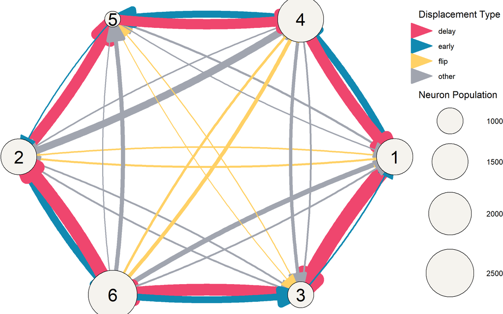

```r
 figure <- plot_displacements(mappings = mappings,  # Looks for nodes inside mapping mapping[["neurons_sizes"]]
                 links =  net_edges_C3toPK, #the arrows in the graph
                 reference_condition = "C3", #used for determine the size of the neurons
                 layout="circle",  #from igraph: circle, linear, grid, etc.
                 node_order=c(1,4,5,2,6,3),  #use a specific order for visualization purposes
                 color_edges = "disp_type",  #Color the arrows by...
                 color_scale=c("#ef466e","#1189b1ff","#ffd166ff", "#a1a5afff", "black"))

figure
```

### 5.2 Displacements of a specific group of biological variables

You can also select a subset of biological variables and visualize their displacements. For instance, based on the work of *Prochetto et al., 2023*, we have compiled a list of 25 genes related to the “photorespiration” process. This allows us to investigate whether there’s a distinct pattern of displacement for this particular group of genes.

```r
# Photorespiration (25) gene list
photo.genes <- c("OG0000295", "OG0000378", "OG0000783", "OG0000964", "OG0001962",
               "OG0002384", "OG0003519", "OG0003992", "OG0004041", "OG0004061",
               "OG0004294", "OG0004978", "OG0005385", "OG0005556", "OG0006771",
               "OG0007574", "OG0007822", "OG0008057", "OG0010248", "OG0012065",
               "OG0012541", "OG0000516", "OG0011137", "OG0001049", "OG0005515")

# Select genes from mappings[["classes"]]
selected_variables <- mappings[["classes"]][mappings[["classes"]]$bio_var %in% photo.genes,]
mappings_selected_variables <- mappings
mappings_selected_variables$classes <- selected_variables



# Build net_edges for the list using the net_edges function
net_edges_pk_photo <- net_edges(mappings_selected_variables,
                                     "C3", "PK",
                                     add_disp_type = TRUE,
                                     disp_type = displacements)
head(net_edges_pk_photo, 10)
```

```
#>    Source Target     Type Id weight disp% disp_type
#> 1       1      1 Directed NA      0   NaN      none
#> 2       1      2 Directed NA      0   NaN      flip
#> 3       1      3 Directed NA      0   NaN     delay
#> 4       1      4 Directed NA      0   NaN     early
#> 5       1      5 Directed NA      0   NaN     other
#> 6       1      6 Directed NA      0   NaN     other
#> 7       2      1 Directed NA      0     0      flip
#> 8       2      2 Directed NA      0     0      none
#> 9       2      3 Directed NA      0     0     other
#> 10      2      4 Directed NA      0     0     other
```

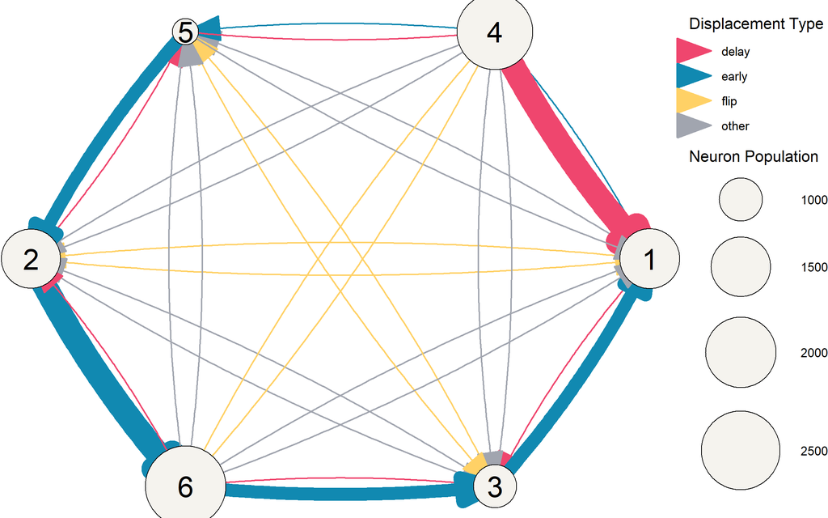

```r
plot_displacements(mappings = mappings_selected_variables,
                links = net_edges_pk_photo,
                reference_condition = "C3",
                layout="circle",
                node_order = c(1,4,5,2,6,3),
                color_edges = "disp_type",
                color_scale=c("#ef466e","#1189b1ff","#ffd166ff", "#a1a5afff", "black")
                )
```

With this analysis, you can explore the displacement patterns for this specific group of genes associated with “photorespiration.” This can provide valuable insights into how these genes expression pattern have changed and their relationships between the reference species (C3) and the test species (PK).

### 5.3 Photosynthesis as a Case Study

In previous steps we integrated transcriptomic data with anatomical information from four leaf segments representing different developmental stages. After scaling the data, an optimal map size of 2x3 was determined for our dataset comprising 9757 biological variables. The resulting map consisted of 6 neurons, each exhibiting distinct expression patterns. Following this, we constructed a reference SOM utilizing data from the C3 species, and subsequently, we mapped the data from PK and C4 onto this reference SOM for further analysis. Our analysis centered on inner bundle sheath (IBS) cell size, a crucial phenotypic trait in C4 anatomy. Our results show that the phenotypic trait IBS cell area is preserved between C3 and PK species (In both species was mapped to neuron 1) but it is displaced to neuron 6 in C4 species. We can access to this information looking for the *“classes”* dataframe inside *“mappings”* object created in step 3.1.

```r
head(mappings[["classes"]], 10)
```

```
#>            bio_var Class1 Class2 Class3 C3 PK C4 control_condition
#> 1      VB Distance    PhT     vb   <NA>  3  2  4                 3
#> 2       VB Density    PhT     vb   <NA>  2  4  6                 2
#> 3  1 VB / Total VB    PhT     vb   <NA>  4  4  4                 4
#> 4      VB Diameter    PhT     vb   <NA>  1  4  4                 1
#> 5        VB Area %    PhT     vb   <NA>  4  4  4                 4
#> 6    IBS Cell size    PhT     bs   <NA>  1  1  6                 1
#> 7       IBS Area %    PhT     bs   <NA>  5  4  3                 5
#> 8    OBS Cell size    PhT     bs   <NA>  1  3 NA                 1
#> 9       OBS Area %    PhT     bs   <NA>  3  1 NA                 3
#> 10     M Cell size    PhT  other   <NA>  1  5  3                 1
```

Now we can select all biological variables mapped to neuron 1 in both C3 and PK

```r
#
selected_variables <- mappings[["classes"]][mappings$classes$C3 %in% 1 & mappings$classes$PK %in% 1 ,]

head(selected_variables) # 404 biological variables
```

```
#>           bio_var                Class1 Class2              Class3 C3 PK C4
#> 6   IBS Cell size                   PhT     bs                <NA>  1  1  6
#> 35      OG0000028                  <NA>   <NA>                <NA>  1  1  4
#> 44      OG0000044                  <NA>   <NA>                <NA>  1  1  1
#> 99      OG0000117                  <NA>   <NA>                <NA>  1  1  6
#> 166     OG0000200                  <NA>   <NA>                <NA>  1  1  1
#> 192     OG0000231 cell wall development   <NA> lignin biosynthesis  1  1  3
#>     control_condition
#> 6                   1
#> 35                  1
#> 44                  1
#> 99                  1
#> 166                 1
#> 192                 1
```

We also can plot these displacement regarding from C3 and PK to C4

```r
# Select genes from mappings[["classes"]]
mappings_selected_variables <- mappings
mappings_selected_variables$classes <- selected_variables

# Build net_edges for the list using the net_edges function
net_edges_selected_variables <- net_edges(mappings_selected_variables,
                                     "C3", "C4",
                                     add_disp_type = TRUE,
                                     disp_type = displacements)

head(net_edges_selected_variables, 10)
```

```
#>    Source Target     Type Id weight     disp% disp_type
#> 1       1      1 Directed NA    199 49.257426      none
#> 2       1      2 Directed NA     13  3.217822      flip
#> 3       1      3 Directed NA     72 17.821782     delay
#> 4       1      4 Directed NA     63 15.594059     early
#> 5       1      5 Directed NA     15  3.712871     other
#> 6       1      6 Directed NA     42 10.396040     other
#> 7       2      1 Directed NA      0       NaN      flip
#> 8       2      2 Directed NA      0       NaN      none
#> 9       2      3 Directed NA      0       NaN     other
#> 10      2      4 Directed NA      0       NaN     other
```

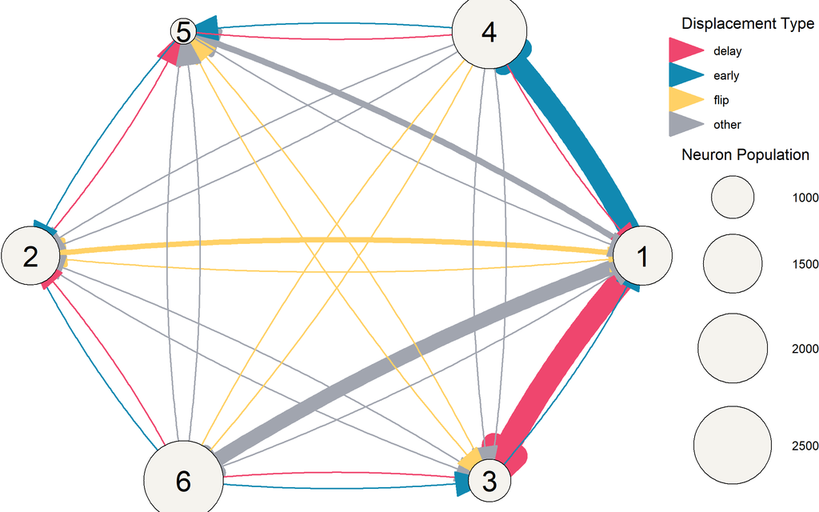

```r
plot_displacements(mappings = mappings_selected_variables,  # Looks for nodes inside mapping mapping[["neurons_sizes"]]
                 links =  net_edges_selected_variables, #the arrows in the graph
                 reference_condition = "C3", #used for determine the size of the neurons
                 layout="circle",  #from igraph: circle, linear, grid, etc.
                 node_order=c(1,4,5,2,6,3),  #use a specific order for visualization purposes
                 color_edges = "disp_type",  #Color the arrows by...
                 color_scale=c("#ef466e","#1189b1ff","#ffd166ff", "#a1a5afff", "black"))
```

Select biological variables displaced together with IBS Cell size:

```r
head(selected_variables)  #IBS cell size is mapped to Neuron 6 in C4.
```

```
#>           bio_var                Class1 Class2              Class3 C3 PK C4
#> 6   IBS Cell size                   PhT     bs                <NA>  1  1  6
#> 35      OG0000028                  <NA>   <NA>                <NA>  1  1  4
#> 44      OG0000044                  <NA>   <NA>                <NA>  1  1  1
#> 99      OG0000117                  <NA>   <NA>                <NA>  1  1  6
#> 166     OG0000200                  <NA>   <NA>                <NA>  1  1  1
#> 192     OG0000231 cell wall development   <NA> lignin biosynthesis  1  1  3
#>     control_condition
#> 6                   1
#> 35                  1
#> 44                  1
#> 99                  1
#> 166                 1
#> 192                 1
```

```r
ibs_displaced_bv <- selected_variables[selected_variables$C4 %in% 6,1]
ibs_displaced_bv
```

```
#>  [1] "IBS Cell size" "OG0000117"     "OG0000276"     "OG0000296"
#>  [5] "OG0000912"     "OG0001125"     "OG0001489"     "OG0001596"
#>  [9] "OG0002160"     "OG0002460"     "OG0002606"     "OG0002718"
#> [13] "OG0003362"     "OG0003543"     "OG0004180"     "OG0004441"
#> [17] "OG0005227"     "OG0005401"     "OG0005527"     "OG0005715"
#> [21] "OG0005759"     "OG0006718"     "OG0007309"     "OG0007427"
#> [25] "OG0007536"     "OG0007857"     "OG0008185"     "OG0009002"
#> [29] "OG0010665"     "OG0011108"     "OG0011332"     "OG0011788"
#> [33] "OG0012289"     "OG0012428"     "OG0013594"     "OG0014299"
#> [37] "OG0014553"     "OG0016954"     "OG0017387"     "OG0018372"
#> [41] "OG0018714"     "OG0021416"
```

Among the displaced genes were two known components of suberin biosynthesis, a characteristic polymer in C4 bundle sheath cell walls. Additionally, our analysis identified two displaced transcription factors, suggesting potential regulatory mechanisms underlying the observed phenotypic shift. We can also use this list of biological variables to perform some kind of enrichment analysis, depending on the annotation information available. For example a GO enrichment analysis showed that this group of genes is significantly enriched in suberin biosynthetic process, pyruvate transport and cell wall modification, among others (Prochetto et al., 2024).

## Citation

For more information, please refer to our paper: